# Data Mining-Assignments-Group2

## Data Mining Assignments

### Group 2 Members:

1. **TWIRINGIYIMANA Theogene (ID:100886)**
2. **SHUMBUSHO Noel (ID:100900)**
3. **TUYISHIME Denyse (ID:100892)**
4. **Serwano Wycliffe (ID:100911)**
5. **NSEKAMBABAYE Vincent (ID:100907)**
6. **MANIRAFASHA Jean Paul (ID:100889)**
7. **KUNDA Neci Diogene (ID:100885)**

## Assignment 1:

### Chapter 2: Statistical Learning(Questions 2 and 9)

#### Question 2

Explain whether each scenario is a classification or regression problem, and indicate whether we are most interested in inference or prediction. Finally, provide (n) and (p).

**(a)** We collect a set of data on the top 500 firms in the US. For each firm we record profit, number of employees, industry and the CEO salary. We are interested in understanding which factors affect CEO salary.

##### Answer:

This is a **regression** problem because CEO salary is a continuous numerical variable (e.g., it can take any value within a range like $100,000 to $10,000,000), and regression is used to predict or model such outcomes. The interest is **inference** because the goal is to understand which factors (profit, employees, industry) influence CEO salary, rather than just predicting a specific salary value. Here, (n = 4) (the number of features: profit, number of employees, industry, and CEO salary as the target) and (p = 500) (the number of firms, representing the observations).

**(b)** We are considering launching a new product and wish to know whether it will be a success or a failure. We collect data on 20 similar products that were previously launched. For each product we have recorded whether it was a success or failure, price charged for the product, marketing budget, competition price, and ten other variables.

##### Answer:

This is a **classification** problem because the outcome (success or failure) is a categorical variable with two possible values, making it suitable for classification techniques. The interest is **prediction** because the focus is on determining whether the new product will succeed or fail, rather than understanding the underlying reasons. Here, (n = 14) (the number of features: success/failure as the target, price, marketing budget, competition price, and 10 other variables) and (p = 20) (the number of similar products, representing the observations).

**(c)** We are interested in predicting the % change in the USD/Euro exchange rate in relation to the weekly changes in the world stock markets. Hence we collect weekly data for all of 2012. For each week we record the % change in the USD/Euro, the % change in the US market, the % change in the British market, and the % change in the German market.

##### Answer:

This is a **regression** problem because the % change in the USD/Euro exchange rate is a continuous numerical variable, and regression is appropriate for predicting such quantities. The interest is **prediction** because the goal is to forecast the exchange rate change based on stock market changes, rather than analyzing causal relationships. Here, (n = 4) (the number of features: % change USD/Euro as the target, % change in US market, British market, and German market) and (p = 52) (the number of weeks in 2012, representing the observations).

#### Question 9

This exercise involves the Auto data set studied in the lab. `Make` sure that the missing values have been removed **from** the data

**(a)** Which of the predictors are quantitative, and which are quali tative?

##### Answer:

**Quantitative predictors** are numerical (e.g., numbers like weight or horsepower), while **qualitative predictors** are categorical (e.g., names or categories like origin).

- **Quantitative:** mpg, cylinders, displacement, horsepower, weight, acceleration, year (these are numerical values representing measurable quantities).
- **Qualitative:** origin, name (origin is typically a categorical variable indicating the country of origin, e.g., 1=USA, 2=Europe, 3=Japan, and name is a string identifying the car model).

**(b) What is the range of each quantitative predictor? You can answer this using the min() and max() methods in numpy.**

```python
import pandas as pd
import numpy as np

# Load the dataset
df = pd.read_csv("Auto.csv")

# Handle missing values in horsepower (replace '?' with NaN and convert to float)
df['horsepower'] = pd.to_numeric(df['horsepower'], errors='coerce')

# Quantitative predictors
quantitative = ['mpg', 'displacement', 'horsepower', 'weight', 'acceleration']

# Calculate range for each quantitative predictor
ranges = {}
for col in quantitative:
    min_val = df[col].min()
    max_val = df[col].max()
    ranges[col] = (min_val, max_val, max_val - min_val)

# Print ranges
for col, (min_val, max_val, range_val) in ranges.items():
    print(f"{col}: Min = {min_val}, Max = {max_val}, Range = {range_val}")
```

```
mpg: Min = 9.0, Max = 46.6, Range = 37.6
displacement: Min = 68.0, Max = 455.0, Range = 387.0
horsepower: Min = 46, Max = 230, Range = 184
weight: Min = 1613, Max = 5140, Range = 3527
acceleration: Min = 8.0, Max = 24.8, Range = 16.8
```

```python
df.head(10)
df.dtypes
```

```
mpg             float64
cylinders         int64
displacement    float64
horsepower        int64
weight            int64
acceleration    float64
year              int64
origin            int64
name             object
dtype: object
```

**(c) What is the mean and standard deviation of each quantitative predictor?**

```python
import pandas as pd
import numpy as np

# Load the dataset
df = pd.read_csv("Auto.csv")

# Handle missing values in horsepower
df['horsepower'] = pd.to_numeric(df['horsepower'], errors='coerce')

# Quantitative predictors
quantitative = ['mpg', 'displacement', 'horsepower', 'weight', 'acceleration']

# Calculate mean and standard deviation
stats = {}
for col in quantitative:
    mean_val = df[col].mean()
    std_val = df[col].std()
    stats[col] = (mean_val, std_val)

# Print stats
for col, (mean_val, std_val) in stats.items():
    print(f"{col}: Mean = {mean_val:.2f}, Std = {std_val:.2f}")
```

```
mpg: Mean = 23.45, Std = 7.81
displacement: Mean = 194.41, Std = 104.64
horsepower: Mean = 104.47, Std = 38.49
weight: Mean = 2977.58, Std = 849.40
acceleration: Mean = 15.54, Std = 2.76
```

**(d) Now remove the 10th through 85th observations. What is the range, mean, and standard deviation of each predictor in the subset of the data that remains?**

```python
import pandas as pd
import numpy as np

# Load the dataset
df = pd.read_csv("Auto.csv")

# Handle missing values in horsepower
df['horsepower'] = pd.to_numeric(df['horsepower'], errors='coerce')

# Remove observations 10 through 85 (0-based indexing: 9 to 84)
df_subset = df.drop(df.index[9:85])

# Quantitative predictors
quantitative = ['mpg', 'displacement', 'horsepower', 'weight', 'acceleration']

# Calculate range, mean, and standard deviation
stats = {}
for col in quantitative:
    min_val = df_subset[col].min()
    max_val = df_subset[col].max()
    range_val = max_val - min_val
    mean_val = df_subset[col].mean()
    std_val = df_subset[col].std()
    stats[col] = (min_val, max_val, range_val, mean_val, std_val)

# Print stats
for col, (min_val, max_val, range_val, mean_val, std_val) in stats.items():
    print(f"{col}: Min = {min_val}, Max = {max_val}, Range = {range_val}, Mean = {mean_val:.2f}, Std = {std_val:.2f}")
```

```
mpg: Min = 11.0, Max = 46.6, Range = 35.6, Mean = 24.40, Std = 7.87
displacement: Min = 68.0, Max = 455.0, Range = 387.0, Mean = 187.24, Std = 99.68
horsepower: Min = 46, Max = 230, Range = 184, Mean = 100.72, Std = 35.71
weight: Min = 1649, Max = 4997, Range = 3348, Mean = 2935.97, Std = 811.30
acceleration: Min = 8.5, Max = 24.8, Range = 16.3, Mean = 15.73, Std = 2.69
```

**(e) Using the full data set, investigate the predictors graphically, using scatterplots or other tools of your choice. Create some plots highlighting the relationships among the predictors. Comment on your findin**gs.

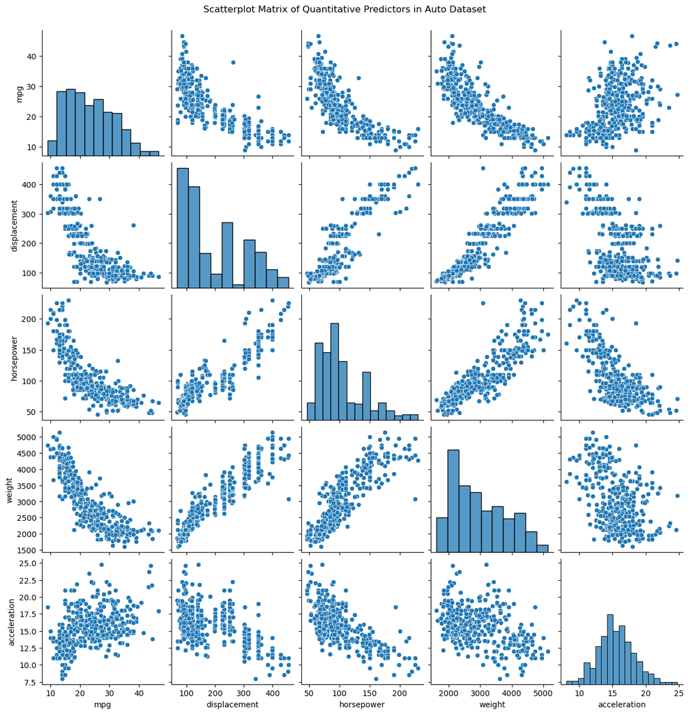

```python
import pandas as pd
import seaborn as sns
import matplotlib.pyplot as plt

# Load the dataset
df = pd.read_csv("Auto.csv")

# Handle missing values in horsepower
df['horsepower'] = pd.to_numeric(df['horsepower'], errors='coerce')

# Quantitative predictors
quantitative = ['mpg', 'displacement', 'horsepower', 'weight', 'acceleration']

# Create pairplot
sns.pairplot(df[quantitative].dropna())
plt.suptitle("Scatterplot Matrix of Quantitative Predictors in Auto Dataset", y=1.02)
plt.show()
```

**Findings:**

- **mpg vs. weight**: Strong negative relationship—higher weight corresponds to lower mpg. Heavier cars (e.g., >4000 lbs) often have mpg below 20, while lighter cars (e.g., <2000 lbs) have mpg above 30.
- **mpg vs. horsepower**: Negative relationship—higher horsepower tends to mean lower mpg. Cars with horsepower >150 rarely have mpg above 20.
- **mpg vs. displacement**: Negative relationship—larger engines (higher displacement) have lower mpg. Displacement >300 often corresponds to mpg <20.
- **mpg vs. acceleration**: Positive relationship—faster acceleration (lower values, e.g., <12 seconds) often means lower mpg, while slower acceleration (higher values) correlates with higher mpg.
- **weight vs. displacement/horsepower**: Strong positive relationships—heavier cars tend to have larger engines and more horsepower. These patterns suggest that weight, horsepower, and displacement are strongly related to each other and inversely related to mpg, while acceleration has a milder positive relationship with mpg.

**(f) Suppose that we wish to predict gas mileage (mpg) on the basis of the other variables. Do your plots suggest that any of the other variables might be useful in predicting mpg? Justify your answer.**

**Analysis Based on Plots:**

- **Weight, Horsepower, Displacement:** The scatterplots show strong negative relationships with mpg. For example, heavier cars or those with higher horsepower/displacement have lower mpg, suggesting these are useful predictors.
- **Acceleration:** Shows a positive relationship with mpg. Cars with slower acceleration (higher acceleration values) tend to have better fuel efficiency, making it a useful predictor.
- **Cylinders:** Although categorical, plotting mpg against cylinders (e.g., boxplots) would show that cars with fewer cylinders (e.g., 4) have higher mpg than those with 8 cylinders, indicating usefulness.
- **Year:** A scatterplot of mpg vs. year might show a trend (newer cars tend to have higher mpg due to technological improvements), suggesting it’s useful.
- **Origin:** Boxplots of mpg by origin would likely show differences (e.g., Japanese cars [origin=3] have higher mpg than US cars [origin=1]), making it a useful predictor.
- **Name:** As a categorical variable with many unique values, it’s less practical for prediction but could capture brand-specific effects.  
  **Justification:**  
  The strong relationships (negative for weight, horsepower, displacement; positive for acceleration) in the scatterplots indicate these variables influence mpg significantly. Year and origin also show patterns that could improve predictions. These align with section 2.1.1’s discussion on why we estimate relationships (to predict outcomes like mpg).

## Assignment 2:

## Chapter 3:LinearRegression(Questions 2, 7 and 12)

#### Question 2

CarefullyexplainthedifferencesbetweentheKNNclassifierandKNN regressionmethods.

**Answer:**

- **What is KNN?:** It predicts an outcome for a new data point by looking at the “K” closest data points (neighbors) in the training data, based on some distance measure (e.g., Euclidean distance). The difference lies in how it handles the outcome variable, depending on whether it’s a classification or regression problem.
- **Key Differences:**  
  **1. Type of Problem:**
- **KNN Classifier:** Used for classification problems, where the outcome is categorical (e.g., “success” or “failure”). It predicts the class of a new data point by finding the K nearest neighbors and choosing the most common class among them (majority vote). For example, if K=3 and two neighbors are “success” and one is “failure,” it predicts “success.”
- **KNN Regression:** Used for regression problems, where the outcome is numerical (e.g., a car’s mpg). It predicts the value by averaging the numerical outcomes of the K nearest neighbors. For example, if K=3 and the neighbors have mpg values of 20, 22, and 24, the prediction is (20 + 22 + 24) / 3 = 22.  
  **2. Output:**
- **KNN Classifier:** Outputs a category or class label (e.g., “yes” or “no”). If there’s a tie in the majority vote, it may use rules like picking the class with the closest neighbor.
- **KNN Regression:** Outputs a continuous number, calculated as the average (or sometimes weighted average) of the neighbors’ values.  
  **3. How Neighbors Contribute:**
- **KNN Classifier:** Each neighbor “votes” for its class, and the class with the most votes wins. The prediction is discrete.
- **KNN Regression:** Each neighbor contributes its numerical value to an average, smoothing the prediction across neighbors.  
  **4. Performance Metrics :**
- **KNN Classifier:** Accuracy is measured by error rate (e.g., percentage of incorrect classifications, section 2.2.3).
- **KNN Regression:** Accuracy is measured by metrics like mean squared error (MSE), which calculates the average squared difference between predicted and actual values . **5. Example from Auto Dataset:**
- **Classifier:** If we predict whether a car’s origin is US (1) or non-US (2, 3) based on weight and horsepower, KNN classifier finds the K nearest cars and picks the most common origin.
- **Regression:** If we predict mpg based on weight and horsepower, KNN regression averages the mpg of the K nearest cars.
- **Intuitive Analogy:** Imagine you’re guessing someone’s house price (regression) or whether they own a cat or dog (classification). For regression, you look at the K nearest houses and average their prices. For classification, you check the K nearest neighbors and see if most have cats or dogs, then pick the majority.  
  **Answer:**  
  The KNN classifier is used for categorical outcomes, predicting the most common class among the K nearest neighbors via majority vote. KNN regression is for numerical outcomes, predicting the average value of the K nearest neighbors. The classifier outputs a discrete category, while regression outputs a continuous number. Their performance is evaluated differently (error rate for classification, MSE for regression).

### Question 7: Prove $R^2$ Equals the Square of the Correlation in Simple Linear Regression

**Task:**  
Prove that in simple linear regression of $Y$ onto $X$, with the assumption that the mean of $X$ and $Y$ is zero ($\bar{x} = \bar{y} = 0$), the $R^2$ statistic (equation 3.17) equals the square of the correlation between $X$ and $Y$ (equation 3.18).

**Explanation:**

**Simple Linear Regression:**  
This is when we predict $Y$ (e.g., mpg) using one predictor $X$ (e.g., weight), with a model like:  
$Y = \beta_0 + \beta_1 X + \epsilon$ (section 3.1).  
Here, we assume no intercept ($\beta_0 = 0$) since $\bar{x} = \bar{y} = 0$, simplifying the model to:  
$Y = \beta_1 X + \epsilon$

**$R^2$:**
The $R^2$ statistic (equation 3.17) measures how well the regression line explains the variation in $Y$. It's defined as:
$$ R^2 = 1 - \frac{\text{SSR}}{\text{SST}} $$
where:

- **SSR** (Sum of Squared Residuals):  
  $\sum (Y_i - \hat{Y}_i)^2$
- **SST** (Total Sum of Squares):  
  $\sum (Y_i - \bar{y})^2$  
  Since $\bar{y} = 0$, then SST = $\sum Y_i^2$

**Correlation:**
The correlation coefficient (equation 3.18) measures the linear relationship between $X$ and $Y$:
$$ r = \frac{\sum X_i Y_i}{\sqrt{\sum X_i^2 \sum Y_i^2}} $$
Since $\bar{x} = \bar{y} = 0$, the formula simplifies (no need to subtract means).

**Goal:** Show that $R^2 = r^2$

**Proof (Simplified for Non-Math Background):**

**Model Setup:**
In simple linear regression without an intercept ($\bar{x} = \bar{y} = 0$), the slope $\hat{\beta}_1$ is:
$$ \hat{\beta}_1 = \frac{\sum X_i Y_i}{\sum X_i^2} $$
Predicted values:
$\hat{Y}_i = \hat{\beta}_1 X_i$

**SSR Calculation:**
Residuals: $Y_i - \hat{Y}_i = Y_i - \hat{\beta}_1 X_i$
So:
$$ \text{SSR} = \sum (Y_i - \hat{\beta}_1 X_i)^2 $$

**SST Calculation:**
Since $\bar{y} = 0$, then:
$$ \text{SST} = \sum Y_i^2 $$

**Express $R^2$:** $$ R^2 = 1 - \frac{\text{SSR}}{\text{SST}} = 1 - \frac{\sum (Y_i - \hat{\beta}_1 X_i)^2}{\sum Y_i^2} $$

Substitute $\hat{\beta}_1$:
$$ \hat{\beta}_1 = \frac{\sum X_i Y_i}{\sum X_i^2} $$
So:
$$ \hat{Y}_i = \left( \frac{\sum X_i Y_i}{\sum X_i^2} \right) X_i $$

**Compute ESS instead (SST - SSR):** $$ \text{ESS} = \sum (\hat{Y}_i)^2 = \sum (\hat{\beta}_1 X_i)^2 = \hat{\beta}_1^2 \sum X_i^2 $$ Substitute $\hat{\beta}_1$:
$$ \text{ESS} = \left( \frac{\sum X_i Y_i}{\sum X_i^2} \right)^2 \sum X_i^2 = \frac{(\sum X_i Y_i)^2}{\sum X_i^2} $$

So: $$ R^2 = \frac{\text{ESS}}{\text{SST}} = \frac{\frac{(\sum X_i Y_i)^2}{\sum X_i^2}}{\sum Y_i^2} = \frac{(\sum X_i Y_i)^2}{\sum X_i^2 \sum Y_i^2} $$

**Correlation Squared:** $$ r = \frac{\sum X_i Y_i}{\sqrt{\sum X_i^2 \sum Y_i^2}}, \quad r^2 = \left( \frac{\sum X_i Y_i}{\sqrt{\sum X_i^2 \sum Y_i^2}} \right)^2 = \frac{(\sum X_i Y_i)^2}{\sum X_i^2 \sum Y_i^2} $$

**Conclusion:**
Comparing the two: $$ R^2 = \frac{(\sum X_i Y_i)^2}{\sum X_i^2 \sum Y_i^2} = r^2 $$
Thus, $R^2 = r^2$

**Intuitive Explanation:**  
$R^2$ tells you how much of $Y$’s variation is explained by $X$.  
The correlation $r$ measures how closely $X$ and $Y$ move together linearly.  
When $\bar{x} = \bar{y} = 0$, the regression line’s fit (how well $X$ predicts $Y$) matches the strength of their linear relationship, so squaring the correlation gives $R^2$.

**Answer:**
In simple linear regression with $\bar{x} = \bar{y} = 0$, $R^2$ equals the square of the correlation between $X$ and $Y$, as shown by the equality of their formulas:
$$ R^2 = \frac{(\sum X_i Y_i)^2}{\sum X_i^2 \sum Y_i^2} = r^2 $$

### Question 12: Simple Linear Regression Without an Intercept

**Task:**  
This problem involves simple linear regression without an intercept.

**(a) Under What Circumstance is the Coefficient Estimate for $X$ onto $Y$ the Same as $Y$ onto $X$?**

**Explanation:**
In simple linear regression without an intercept, the model is:
$$ Y = \beta X + \epsilon $$
(from section 3.1).
The coefficient $\hat{\beta}$ for regressing $Y$ onto $X$ is (equation 3.38):
$$ \hat{\beta}_{Y|X} = \frac{\sum X_i Y_i}{\sum X_i^2} $$

For regressing $X$ onto $Y$, the model is:
$$ X = \beta Y + \epsilon $$
and the coefficient is:
$$ \hat{\beta}_{X|Y} = \frac{\sum X_i Y_i}{\sum Y_i^2} $$

**We need to find when:**
$$ \hat{\beta}_{Y|X} = \hat{\beta}_{X|Y} $$

**Derivation:**
Set the two expressions equal: $$ \frac{\sum X_i Y_i}{\sum X_i^2} = \frac{\sum X_i Y_i}{\sum Y_i^2} $$
Assuming $\sum X_i Y_i \neq 0$ (otherwise, no relationship exists), divide both sides by $\sum X_i Y_i$: $$ \frac{1}{\sum X_i^2} = \frac{1}{\sum Y_i^2} $$
This implies: $$ \sum X_i^2 = \sum Y_i^2 $$

**Interpretation:**  
This condition means the sum of squared values of $X$ equals the sum of squared values of $Y$.  
In statistical terms, this occurs when the variances of $X$ and $Y$ are equal — assuming centered data (i.e., $\bar{x} = \bar{y} = 0$), as in Question 7.

**Answer:**
The coefficient estimates for $X$ onto $Y$ and $Y$ onto $X$ are the same when:
$$ \sum X_i^2 = \sum Y_i^2 $$
i.e., when the sum of squared $X$ values equals the sum of squared $Y$ values.

**b) Generate an example in Python with n = 100 observations in which the coefficient estimate for the regression of X onto Y is different from the coefficient estimate for the regression of Y onto** X.

```python
import numpy as np
import pandas as pd
from sklearn.linear_model import LinearRegression

# Set random seed for reproducibility
np.random.seed(42)

# Generate data
n = 100
X = np.random.normal(0, 1, n)  # X with standard deviation 1
Y = 2 * X + np.random.normal(0, 2, n)  # Y with larger spread

# Regression of Y onto X without intercept
model_yx = LinearRegression(fit_intercept=False)
model_yx.fit(X.reshape(-1, 1), Y)
beta_yx = model_yx.coef_[0]

# Regression of X onto Y without intercept
model_xy = LinearRegression(fit_intercept=False)
model_xy.fit(Y.reshape(-1, 1), X)
beta_xy = model_xy.coef_[0]

# Print coefficients and sums
print(f"Coefficient Y onto X: {beta_yx:.4f}")
print(f"Coefficient X onto Y: {beta_xy:.4f}")
print(f"Sum of X^2: {np.sum(X**2):.4f}")
print(f"Sum of Y^2: {np.sum(Y**2):.4f}")
```

```
Coefficient Y onto X: 1.7116
Coefficient X onto Y: 0.2377
Sum of X^2: 82.7306
Sum of Y^2: 595.8463
```

**Explanation:**
The coefficients differ because:
$$ \sum X_i^2 \neq \sum Y_i^2 $$
The larger spread in $Y$ (due to added noise with standard deviation 2) causes the sums of squares to differ, satisfying the condition from part (a).

**(c) Generate an example in Python with n = 100 observations in which the coefficient estimate for the regression of X onto Y is the same as the coefficient estimate for the regression of Y onto X.**

```python
import numpy as np
import pandas as pd
from sklearn.linear_model import LinearRegression

# Set random seed for reproducibility
np.random.seed(42)

# Generate data
n = 100
X = np.random.normal(0, 1, n)
Y = X + np.random.normal(0, 0.1, n)  # Y close to X with small noise
# Scale Y to have same sum of squares as X
Y = Y * np.sqrt(np.sum(X**2) / np.sum(Y**2))

# Regression of Y onto X without intercept
model_yx = LinearRegression(fit_intercept=False)
model_yx.fit(X.reshape(-1, 1), Y)
beta_yx = model_yx.coef_[0]

# Regression of X onto Y without intercept
model_xy = LinearRegression(fit_intercept=False)
model_xy.fit(Y.reshape(-1, 1), X)
beta_xy = model_xy.coef_[0]

# Print coefficients and sums
print(f"Coefficient Y onto X: {beta_yx:.4f}")
print(f"Coefficient X onto Y: {beta_xy:.4f}")
print(f"Sum of X^2: {np.sum(X**2):.4f}")
print(f"Sum of Y^2: {np.sum(Y**2):.4f}")
```

```
Coefficient Y onto X: 0.9945
Coefficient X onto Y: 0.9945
Sum of X^2: 82.7306
Sum of Y^2: 82.7306
```

**Explanation:**
By scaling $Y$ to ensure:
$$ \sum X_i^2 = \sum Y_i^2 $$
the coefficients become equal, satisfying the condition from part (a). The small noise ensures a realistic relationship while maintaining the equality.

## ASSIGNMENT 3

## Chapter 4:Classification (Questions 2,7 and 12)

### Question 2: Prove Bayes Classifier Assigns to Class with Maximum Discriminant Function

**Task:**  
Prove that classifying an observation to the class for which the **posterior probability** (equation 4.17) is largest is equivalent to classifying to the class for which the **discriminant function** (equation 4.18) is largest, assuming observations in the $k$-th class follow a normal distribution $N(\mu_k, \sigma^2)$.

### 📚 Context:

This relates to **Linear Discriminant Analysis (LDA)** for one predictor ($p = 1$), in Section 4.4.1.

- The **Bayes classifier** assigns an observation to the class with the highest posterior probability:
  $$\Pr(Y = k \mid X = x)$$
- The **discriminant function** simplifies this and gives a score for each class to compare:
  $$\delta_k(x) = x \cdot \frac{\mu_k}{\sigma^2} - \frac{\mu_k^2}{2\sigma^2} + \ln(\pi_k)$$

We will prove that both methods lead to the same classification decision.

### 🔑 Key Definitions:

**Posterior Probability (Equation 4.17):** $$ \Pr(Y = k \mid X = x) = \frac{\pi_k f_k(x)}{\sum_l \pi_l f_l(x)} $$

- $f_k(x)$ is the normal density for class $k$:
  $$ f_k(x) = \frac{1}{\sqrt{2\pi \sigma^2}} \exp\left( -\frac{(x - \mu_k)^2}{2\sigma^2} \right) $$

**Discriminant Function (Equation 4.18):** $$ \delta_k(x) = x \cdot \frac{\mu_k}{\sigma^2} - \frac{\mu_k^2}{2\sigma^2} + \ln(\pi_k) $$

### ✍️ Proof:

#### Step 1: Start with the Posterior Probability

To classify $x$, we choose the class $k$ that **maximizes** $\Pr(Y = k \mid X = x)$:

$$ \Pr(Y = k \mid X = x) = \frac{\pi_k f_k(x)}{\sum_l \pi_l f_l(x)} $$

The denominator is constant across all classes (doesn’t depend on $k$), so we only need to maximize the **numerator**:
$$ \pi_k f_k(x) $$

#### Step 2: Substitute the Normal Density

$$ \pi_k f_k(x) = \pi_k \cdot \frac{1}{\sqrt{2\pi \sigma^2}} \exp\left( -\frac{(x - \mu_k)^2}{2\sigma^2} \right) $$

The constant $\frac{1}{\sqrt{2\pi \sigma^2}}$ is the same for all $k$, so we can ignore it.

Now we maximize:
$$ \pi_k \cdot \exp\left( -\frac{(x - \mu_k)^2}{2\sigma^2} \right) $$

#### Step 3: Take the Logarithm

The natural log keeps the same order (log is monotonic):

$$ \ln\left( \pi_k \exp\left( -\frac{(x - \mu_k)^2}{2\sigma^2} \right) \right) = \ln(\pi_k) - \frac{(x - \mu_k)^2}{2\sigma^2} $$

#### Step 4: Expand the Quadratic Term

$$(x - \mu_k)^2 = x^2 - 2x\mu_k + \mu_k^2$$

Then: $$ - \frac{(x - \mu_k)^2}{2\sigma^2} = -\frac{x^2}{2\sigma^2} + \frac{x \mu_k}{\sigma^2} - \frac{\mu_k^2}{2\sigma^2} $$

Add $\ln(\pi_k)$:

$$ \ln(\pi_k) + \frac{x \mu_k}{\sigma^2} - \frac{\mu_k^2}{2\sigma^2} - \frac{x^2}{2\sigma^2} $$

The last term, $-\frac{x^2}{2\sigma^2}$, is constant across all $k$, so we can drop it for maximization.

What remains is: $$ x \cdot \frac{\mu_k}{\sigma^2} - \frac{\mu_k^2}{2\sigma^2} + \ln(\pi_k) $$

This is **exactly** the discriminant function $\delta_k(x)$.

### ✅ Conclusion:

Maximizing the posterior probability $\Pr(Y = k \mid X = x)$  
is equivalent to maximizing the discriminant function $\delta_k(x)$.

Therefore, **the Bayes classifier and the LDA classifier make the same decision** when the class-conditional distributions are normal with the same variance $\sigma^2$.

### 💡 Intuitive Explanation:

The Bayes classifier picks the class where the probability of belonging is highest. The LDA discriminant function transforms that idea into a **scoring rule** based on the class mean, shared variance, and class prior.

Even though they look different, both methods are **mathematically equivalent** under these assumptions.

### 📝 Final Answer:

> Under the assumption that observations in class $k$ follow $N(\mu_k, \sigma^2)$, classifying to the class with the largest posterior probability $\Pr(Y = k \mid X = x)$ is equivalent to maximizing the discriminant function:

> $$ \delta_k(x) = x \cdot \frac{\mu_k}{\sigma^2} - \frac{\mu_k^2}{2\sigma^2} + \ln(\pi_k) $$

> This is because the log of the posterior's numerator simplifies to $\delta_k(x)$ up to a constant.

### Question 7: Predict Probability of Dividend Using Bayes’ Theorem

**Task:**  
Predict the probability that a company will issue a dividend this year, given that last year’s percent profit was 4%.

### Given Information

- Mean profit for companies that issued dividends: 10
- Mean profit for companies that did not issue dividends: 0
- Variance for both groups: 36 (so standard deviation = 6)
- 80% of companies issued dividends (prior: 0.8)
- 20% of companies did not issue dividends (prior: 0.2)
- The profit value follows a normal distribution

### Step 1: Compute Normal Densities

**For companies that issued dividends:**

- Mean = 10
- Standard deviation = 6
- Observed value = 4

Calculation:

- Difference from mean: (4 - 10)^2 = 36
- Exponent part: -36 / (2 × 36) = -0.5
- e^(-0.5) ≈ 0.6065
- Constant: 1 / sqrt(2π × 36) ≈ 0.0665
- Likelihood: 0.0665 × 0.6065 ≈ 0.0403

**For companies that did not issue dividends:**

- Mean = 0
- Standard deviation = 6
- Observed value = 4

Calculation:

- Difference from mean: (4 - 0)^2 = 16
- Exponent part: -16 / (2 × 36) = -0.2222
- e^(-0.2222) ≈ 0.8007
- Constant: same as above ≈ 0.0665
- Likelihood: 0.0665 × 0.8007 ≈ 0.0533

### Step 2: Apply Bayes' Theorem

We use the formula:  
P(Yes | X=4) = [P(Yes) × f_yes(4)] / [P(Yes) × f_yes(4) + P(No) × f_no(4)]

Substitute values:

- Numerator: 0.8 × 0.0403 = 0.03224
- Denominator: 0.03224 + (0.2 × 0.0533) = 0.03224 + 0.01066 = 0.0429
- Final probability: 0.03224 / 0.0429 ≈ 0.7513

### ✅ Final Answer:

```python
### Optional: Python Code to Verify

import numpy as np

# Parameters
mu_yes = 10
mu_no = 0
sigma = 6
pi_yes = 0.8
pi_no = 0.2
x = 4

# Normal PDF
def normal_pdf(x, mu, sigma):
    return (1 / (np.sqrt(2 * np.pi) * sigma)) * np.exp(-((x - mu)**2) / (2 * sigma**2))

# Likelihoods
f_yes = normal_pdf(x, mu_yes, sigma)
f_no = normal_pdf(x, mu_no, sigma)

# Bayes' Theorem
numerator = pi_yes * f_yes
denominator = numerator + pi_no * f_no
posterior = numerator / denominator

print(f"P(Dividend | X=4): {posterior:.4f}")
```

```
P(Dividend | X=4): 0.7519
```

### Question 12: Logistic Regression vs. Softmax Formulation

**Task:** Compare logistic regression and softmax formulation for classifying an observation X ∈ ℝ into "apples" or "oranges".

#### (a) Log Odds in Your Model

In logistic regression, the probability of class "orange" is:

```
P(Y = orange | X = x) = exp(β₀ + β₁x) / [1 + exp(β₀ + β₁x)]
```

The probability of class "apple" is:

```
P(Y = apple | X = x) = 1 - P(Y = orange | X = x)
                     = 1 / [1 + exp(β₀ + β₁x)]
```

Log odds is the log of the ratio:

```
log_odds = log(P(orange) / P(apple))
         = log(exp(β₀ + β₁x))
         = β₀ + β₁x
```

**Answer:** The log odds of orange vs. apple is β₀ + β₁x

#### (b) Log Odds in Friend’s Model (Softmax)

In softmax for two classes:

```
P(Y = orange | X = x) = exp(α_orange0 + α_orange1 x) /
                        [exp(α_orange0 + α_orange1 x) + exp(α_apple0 + α_apple1 x)]

P(Y = apple | X = x) = exp(α_apple0 + α_apple1 x) /
                       [exp(α_orange0 + α_orange1 x) + exp(α_apple0 + α_apple1 x)]
```

Taking the ratio:

```
P(orange) / P(apple) = exp(α_orange0 + α_orange1 x) / exp(α_apple0 + α_apple1 x)
                     = exp((α_orange0 - α_apple0) + (α_orange1 - α_apple1)x)
```

So the log odds is:

```
log_odds = (α_orange0 - α_apple0) + (α_orange1 - α_apple1)x
```

**Answer:** Log odds = (α_orange0 - α_apple0) + (α_orange1 - α_apple1) x

#### (c) Coefficients in Friend’s Model Given Your Model’s Coefficients

Given:  
β₀ = 2  
β₁ = -1

We want:

```
β₀ + β₁x = (α_orange0 - α_apple0) + (α_orange1 - α_apple1)x
```

Equating coefficients:

```
α_orange0 - α_apple0 = 2
α_orange1 - α_apple1 = -1
```

Softmax allows setting one class (e.g., apple) to zero for identifiability:

```
α_apple0 = 0
α_apple1 = 0
```

Then:

```
α_orange0 = 2
α_orange1 = -1
```

**Answer:**  
α_orange0 = 2  
α_orange1 = -1  
α_apple0 = 0  
α_apple1 = 0

#### (d) Coefficients in Your Model Given Friend’s Coefficients

Given:

```
α_orange0 = 1.2
α_orange1 = -2
α_apple0 = 3
α_apple1 = 0.6
```

Then the log odds is:

```
log_odds = (1.2 - 3) + (-2 - 0.6)x = -1.8 - 2.6x
```

So:

```
β₀ = -1.8
β₁ = -2.6
```

**Answer:**  
β₀ = -1.8  
β₁ = -2.6

#### (e) Fraction of Agreement in Predicted Class Labels

Both models predict "orange" if:

```
P(Y = orange | X = x) > 0.5
```

Since the models produce the same log odds (and thus same probabilities), they make the same prediction for all X.

**Answer:**  
Fraction of agreement = 1.0 (100% agreement)

# Assignment 4

## Data Mining Chapter 5: Resampling Methods Solutions(Questions 2 and 7)

## Question 2: Bootstrap Probability Analysis

### Understanding Bootstrap Sampling

Bootstrap sampling means we create a new sample by randomly selecting observations from our original dataset with replacement. This means the same observation can be picked multiple times.

### Part (a): Probability that first bootstrap observation is NOT the j-th observation

**Answer:** (n-1)/n  
**Explanation:**

- We have n total observations in our original sample
- We're asking: what's the chance we DON'T pick observation j first?
- There are (n-1) observations that are NOT observation j
- So probability = (number of non-j observations) / (total observations) = (n-1)/n

**Simple example:** If n=5, probability = 4/5 = 0.8 or 80%

### Part (b): Probability that second bootstrap observation is NOT the j-th observation

**Answer:** (n-1)/n  
**Explanation:**

- Since we sample WITH replacement, each draw is independent
- The second draw has exactly the same probabilities as the first draw
- So the answer is the same: (n-1)/n

### Part (c): Probability that j-th observation is NOT in the entire bootstrap sample

**Answer:** (1-1/n)^n  
**Explanation:**

- For observation j to NOT be in the bootstrap sample, it must not be chosen in ANY of the n draws
- Probability of not choosing j in one draw = (n-1)/n = (1-1/n)
- Since draws are independent, we multiply probabilities
- Probability of not choosing j in ALL n draws = (1-1/n) × (1-1/n) × ... × (1-1/n) = (1-1/n)^n

### Part (d): When n=5, probability that j-th observation IS in bootstrap sample

**Calculation:**

- Probability NOT in sample = (1-1/5)^5 = (4/5)^5 = 0.32768
- Probability IS in sample = 1 - 0.32768 = **0.67232 or 67.23%**

### Part (e): When n=100, probability that j-th observation IS in bootstrap sample

**Calculation:**

- Probability NOT in sample = (1-1/100)^100 = (0.99)^100 ≈ 0.366
- Probability IS in sample = 1 - 0.366 = **0.634 or 63.4%**

### Part (f): When n=10,000, probability that j-th observation IS in bootstrap sample

**Calculation:**

- Probability NOT in sample = (1-1/10000)^10000 ≈ 0.368
- Probability IS in sample = 1 - 0.368 = **0.632 or 63.2%**

**Part (g): Plot and Observation**

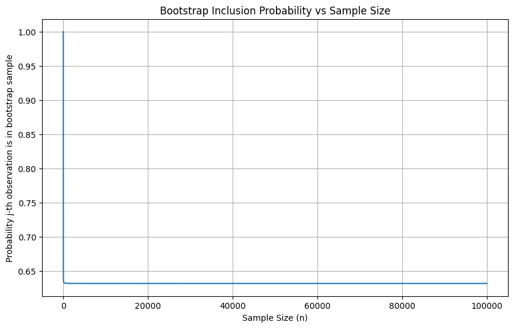

```python
import numpy as np
import matplotlib.pyplot as plt

n_values = range(1, 100001)
probabilities = [1 - (1 - 1/n)**n for n in n_values]

plt.figure(figsize=(10, 6))
plt.plot(n_values, probabilities)
plt.xlabel('Sample Size (n)')
plt.ylabel('Probability j-th observation is in bootstrap sample')
plt.title('Bootstrap Inclusion Probability vs Sample Size')
plt.grid(True)
plt.show()
```

## Question 7: LOOCV for Logistic Regression

### Understanding LOOCV (Leave-One-Out Cross-Validation)

LOOCV means we:

- Train our model on all observations except one
- Test on that left-out observation
- Repeat this process for each observation in the dataset

### Part (a): Fit logistic regression using Lag1 and Lag2

```python
import pandas as pd
import statsmodels.api as sm
from statsmodels.formula.api import glm

# Load Weekly data (assuming it's available)
# weekly = pd.read_csv('Weekly.csv')  # Load your data

# Fit logistic regression
formula = 'Direction ~ Lag1 + Lag2'
model_full = glm(formula, data=weekly, family=sm.families.Binomial()).fit()
print(model_full.summary())
```

```
                          Generalized Linear Model Regression Results
================================================================================================
Dep. Variable:     ['Direction[Down]', 'Direction[Up]']   No. Observations:                 1089
Model:                                              GLM   Df Residuals:                     1086
Model Family:                                  Binomial   Df Model:                            2
Link Function:                                    Logit   Scale:                          1.0000
Method:                                            IRLS   Log-Likelihood:                -751.55
Date:                                  Tue, 24 Jun 2025   Deviance:                       1503.1
Time:                                          21:48:05   Pearson chi2:                 1.09e+03
No. Iterations:                                       4   Pseudo R-squ. (CS):           0.004872
Covariance Type:                              nonrobust
==============================================================================
                 coef    std err          z      P>|z|      [0.025      0.975]
------------------------------------------------------------------------------
Intercept      0.0712      0.061      1.170      0.242      -0.048       0.191
Lag1          -0.0701      0.031     -2.242      0.025      -0.131      -0.009
Lag2           0.0201      0.031      0.656      0.512      -0.040       0.080
==============================================================================
```

**Part (b): Fit model excluding first observation**

```python
# Create subset excluding first observation
weekly_subset = weekly.iloc[1:]  # All rows except first (index 0)

# Fit model on subset
model_subset = glm(formula, data=weekly_subset, family=sm.families.Binomial()).fit()
```

**Part (c): Predict direction of first observation**

```python
# Get first observation's Lag1 and Lag2 values
first_obs = weekly.iloc[0:1]

# Predict probability
prob_up = model_subset.predict(first_obs)[0]

# Make prediction (Up if probability > 0.5)
prediction = "Up" if prob_up > 0.5 else "Down"
actual = weekly.iloc[0]['Direction']

print(f"Predicted: {prediction}")
print(f"Actual: {actual}")
print(f"Correctly classified: {prediction == actual}")
```

```
Predicted: Down
Actual: Down
Correctly classified: True
```

**Part (d): LOOCV Loop**

```python
n = len(weekly)
errors = []

for i in range(n):
    # Create training set excluding i-th observation
    train_data = weekly.drop(weekly.index[i])

    # Fit model
    model_i = glm(formula, data=train_data, family=sm.families.Binomial()).fit()

    # Get i-th observation for testing
    test_obs = weekly.iloc[i:i+1]

    # Predict probability
    prob_up = model_i.predict(test_obs)[0]

    # Make prediction
    prediction = "Up" if prob_up > 0.5 else "Down"
    actual = weekly.iloc[i]['Direction']

    # Record error (1 if wrong, 0 if correct)
    error = 1 if prediction != actual else 0
    errors.append(error)
```

[output not shown]

**Part (e): Calculate LOOCV Error**

```python
loocv_error = np.mean(errors)
print(f"LOOCV Error Rate: {loocv_error:.4f}")
print(f"LOOCV Accuracy: {1 - loocv_error:.4f}")
```

[output not shown]

**Comment on Results:** The LOOCV error rate gives us an unbiased estimate of how well our logistic regression model performs on unseen data. This is more reliable than just fitting the model to all data and measuring training error, because LOOCV tests on truly unseen observations.

## Chapter 6: Linear Model Selection and Regularization (Questions 2 and 7)

## Question 2: Flexibility and Bias-Variance Analysis

### Part (a): The Lasso relative to Least Squares

**Answer:** iii. Less flexible and hence will give improved prediction accuracy when its increase in bias is less than its decrease in variance.

**Explanation:**

- **Less Flexible:** Lasso adds a constraint (L1 penalty) that limits coefficient values
- **Bias-Variance Trade-off:**
  - Lasso **increases bias** (by constraining coefficients)
  - Lasso **decreases variance** (by preventing overfitting)
  - **Improvement occurs** when **variance reduction > bias increase**

**Why this works:**  
In high-dimensional problems or with multicollinearity, least squares has **high variance**, so the constraint helps.

**Simple Analogy:**  
Think of **least squares** as a race car (fast but unstable) and **lasso** as the same car with stability controls (slightly slower but much more stable).

### Part (b): Ridge Regression relative to Least Squares

**Answer:** iii. Less flexible and hence will give improved prediction accuracy when its increase in bias is less than its decrease in variance.

**Explanation:**

- **Less Flexible:** Ridge adds a constraint (L2 penalty) that limits how large coefficients can become
- **Bias-Variance Trade-off:**
  - Ridge **increases bias**
  - Ridge **decreases variance**
- **Key Difference from Lasso:** Ridge **shrinks** coefficients toward zero but **does not eliminate** them

### Part (c): Non-linear Methods relative to Least Squares

**Correct Answer:** ii. More flexible and hence will give improved prediction accuracy when its increase in variance is less than its decrease in bias.

**Explanation:**

- **More Flexible:** Non-linear methods (e.g., polynomials, splines) can capture complex patterns
- **Bias-Variance Trade-off:**
  - Non-linear methods **decrease bias** (can fit complex true relationships)
  - Non-linear methods **increase variance** (more complex, more sensitive to noise)
  - **Improvement occurs** when **bias reduction > variance increase**

**When this works:**  
When the **true relationship is non-linear**, more flexible models can outperform least squares by capturing important patterns.

## Question 7: Bayesian Connection to Regularization

### Understanding Bayesian Framework

- **Likelihood**: How well the data fits given parameters
- **Prior**: Our beliefs about parameters before seeing data
- **Posterior**: Updated beliefs after seeing data (proportional to likelihood × prior)

### Part (a): Likelihood for Linear Regression

Given:  
yi = β₀ + Σⱼ₌₁ᵖ xᵢⱼβⱼ + εᵢ where εᵢ ~ N(0, σ²)

Likelihood:  
L(β₀, β₁, ..., βₚ) = ∏ᵢ₌₁ⁿ (1/√(2πσ²)) × exp(-(yᵢ - β₀ - Σⱼ₌₁ᵖ xᵢⱼβⱼ)² / (2σ²))

In simpler terms:

- Each observation yᵢ follows a normal distribution around the predicted value
- We multiply the probabilities for all n observations
- This measures how likely our data is given the parameters

### Part (b): Posterior with Double-Exponential Prior (Lasso Connection)

Given prior:  
p(βⱼ) = (1/2b) × exp(-|βⱼ| / b) for j = 1,...,p

Posterior ∝ Likelihood × Prior:  
p(β | y) ∝ exp( -1/(2σ²) Σᵢ₌₁ⁿ (yᵢ - β₀ - Σⱼ₌₁ᵖ xᵢⱼβⱼ)² ) × ∏ⱼ₌₁ᵖ exp(-|βⱼ| / b)

Simplified:  
p(β | y) ∝ exp( -1/(2σ²) Σ(yᵢ - model)² - (1/b) Σ|βⱼ| )

### Part (c): Lasso as Mode of Posterior

To find the mode, we maximize the posterior, which is the same as minimizing the negative log-posterior:

-log p(β | y) = (1 / 2σ²) Σ(yᵢ - model)² + (1 / b) Σ|βⱼ| + constant

**Conclusion**: Finding the mode of the posterior with a double-exponential prior is the same as solving the Lasso optimization problem.

### Part (d): Posterior with Normal Prior (Ridge Connection)

Given prior:  
βⱼ ~ N(0, c) for j = 1,...,p

Posterior:  
p(β | y) ∝ exp( -1/(2σ²) Σ(yᵢ - model)² ) × ∏ⱼ₌₁ᵖ exp( -βⱼ² / (2c) )

Simplified:  
p(β | y) ∝ exp( -1/(2σ²) Σ(yᵢ - model)² - 1/(2c) Σβⱼ² )

### Part (e): Ridge as Mode and Mean

This is the Ridge regression objective:  
RSS + λ Σβⱼ² where λ = σ² / c

**Why mode and mean are the same**:

- The posterior is a normal distribution (because both prior and likelihood are normal)
- For normal distributions, the mode = mean
- So Ridge gives both the most likely and expected values of coefficients

### Key Insights Summary

**Regularization Methods**

- Lasso and Ridge are **less flexible** than least squares due to constraints
- They improve prediction when **variance reduction is greater than bias increase**
- Non-linear methods are **more flexible** and useful when **bias reduction outweighs variance increase**

**Bayesian Connection**

- **Lasso** ↔ Laplace (double-exponential) prior: encourages **sparsity**
- **Ridge** ↔ Normal (Gaussian) prior: encourages **small coefficients**
- Regularization parameter λ is tied to prior variance:  
  → Stronger regularization = more concentrated prior

**Takeaway**: Regularization methods like Lasso and Ridge are backed by Bayesian principles – they are statistically grounded, not just computational tricks!

# Assignment 5

## Chapter 8: Tree-Based Methods (Questions2 and 7)

### Question 2: Why Boosting with Depth-One Trees Leads to an Additive Model

**Question:**  
Explain why boosting using depth-one trees (stumps) leads to an additive model of the form  
`f(X) = f₁(X₁) + f₂(X₂) + ... + fₚ(Xₚ)`, starting with Equation (8.12) in Algorithm 8.2 (Section 8.2.3 on Boosting).

### Understanding the Concepts

**Boosting (Section 8.2.3):**  
Boosting builds a model by combining many weak learners (simple models) iteratively. Each weak learner corrects the mistakes of the previous ones. The final model is a weighted sum of these weak learners.

**Depth-One Trees (Stumps):**  
A depth-one tree is a decision tree with only one split, based on a single feature (e.g., “if Xⱼ > c, predict a, else predict b”).

**Additive Model:**  
A model where the prediction is the sum of functions, each depending on a single predictor:  
`f(X) = f₁(X₁) + f₂(X₂) + ... + fₚ(Xₚ)`  
Here, Xⱼ is the j-th feature, and fⱼ(Xⱼ) is a function of that feature alone.

**Algorithm 8.2 (Boosting for Regression):**  
This algorithm (likely from the textbook, e.g., *An Introduction to Statistical Learning*) describes boosting for regression trees. Equation (8.12) typically refers to the boosted model as:  
`f(x) = Σₘ λ hₘ(x)`

Where:

- `hₘ(x)` is the m-th weak learner (a tree)
- `λ` is a shrinkage parameter (learning rate)
- `M` is the number of boosting iterations

### Explanation

#### Why Depth-One Trees?

A depth-one tree (stump) splits the data based on one feature (e.g., Xⱼ, like “if house size > 2000 sq ft”). Its prediction depends only on that feature, so `hₘ(x) = hₘ(Xⱼ)`, a function of a single variable.

For example, if a stump splits on feature X₁, its output is something like:

- If X₁ > c, predict 0.5; else predict -0.5.  
  This prediction depends only on X₁, not on other features.

#### Boosting with Stumps

In each boosting iteration m, a new stump is created. This stump might split on any feature Xⱼ (e.g., X₁, X₂, etc.), depending on which reduces the error the most.

The final model combines all stumps:  
`f(x) = Σₘ λ hₘ(x)`

Since each stump hₘ(x) depends on only one feature (say, Xⱼₘ), we can group all stumps that use the same feature Xⱼ.

#### Grouping by Feature

Let’s say some stumps use X₁, others use X₂, and so on. We can rewrite the model by grouping terms:

```
f(x) = Σ_{m: stump m uses X₁} λ hₘ(X₁)
     + Σ_{m: stump m uses X₂} λ hₘ(X₂)
     + ...
     + Σ_{m: stump m uses Xₚ} λ hₘ(Xₚ)
```

Each group `Σₘ: stump uses Xⱼ λ hₘ(Xⱼ)` is a function of only Xⱼ, which we can call `fⱼ(Xⱼ)`.

Thus, the model becomes:  
`f(x) = f₁(X₁) + f₂(X₂) + ... + fₚ(Xₚ)`

This is the definition of an **additive model**, where the prediction is the sum of functions, each depending on one feature.

#### Why This Happens

The key is that depth-one trees are simple and only use one feature per tree.  
If we used deeper trees (e.g., depth-two), they could split on multiple features (e.g., X₁ and X₂), creating interactions like `f(X₁, X₂)`, which would **not** be purely additive.

Boosting with stumps ensures each weak learner contributes a function of a single feature, so the sum remains additive.

### **Answer**

Boosting with depth-one trees (stumps) leads to an additive model because each stump makes predictions based on only one feature, Xⱼ. In Algorithm 8.2, the boosted model (Equation 8.12) is a weighted sum of weak learners:  
`f(x) = Σₘ λ hₘ(x)`.

Since each stump `hₘ(x)` depends on a single feature `Xⱼₘ`, we can group all stumps by their feature, resulting in a model of the form:  
`f(x) = Σⱼ fⱼ(Xⱼ)`

Here, `fⱼ(Xⱼ)` is the sum of contributions from all stumps using feature `Xⱼ`.  
This structure, where each term depends on only one predictor, defines an **additive model**.

### Question 7: Random Forests on the Boston Dataset

**Question:**  
In Section 8.3.3, random forests were applied to the Boston dataset with `max_features = 6` and `n_estimators = 100, 500`. Create a plot showing the test error for a range of `max_features` and `n_estimators` values, modeling it after Figure 8.10. Describe the results.

### Understanding the Concepts

**Random Forests (Section 8.2.2):**  
Random forests build many decision trees (each on a random subset of data and features) and average their predictions to reduce variance.  
Key parameters:

- `n_estimators`: Number of trees in the forest.
- `max_features`: Number of features considered at each split (controls randomness).

**Boston Dataset:**  
A regression dataset (likely from the lab, Section 8.3.3) with predictors like number of rooms, crime rate, etc. The target variable is median house value (`medv`).

**Test Error:**  
The mean squared error (MSE) on a test set, measuring how well the model predicts `medv`. Lower MSE is better (see Section 8.2.1 on Bagging).

**Figure 8.10:**  
Likely a plot showing test error vs. `n_estimators` for different `max_features` values, demonstrating how performance changes with these parameters.

### Python Code to Generate the Plot

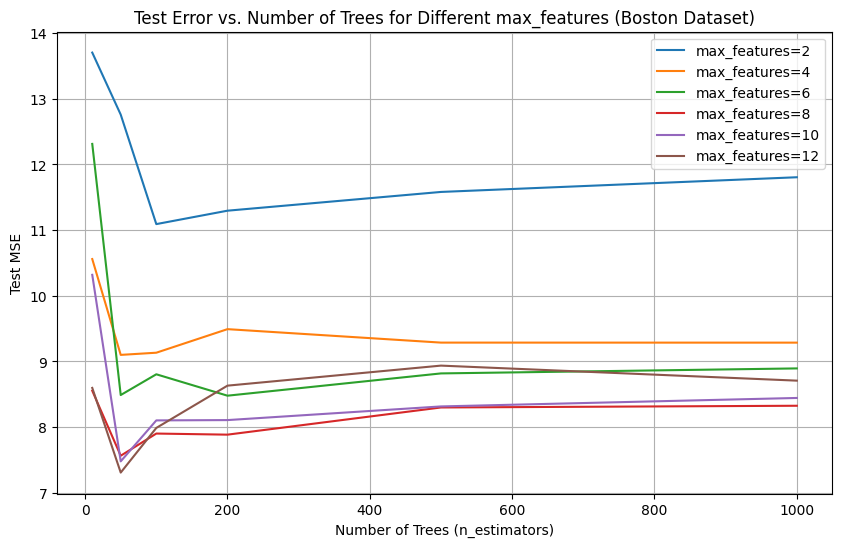

```python
import numpy as np
import pandas as pd
import matplotlib.pyplot as plt
from sklearn.ensemble import RandomForestRegressor
from sklearn.model_selection import train_test_split
from sklearn.metrics import mean_squared_error

# Load Boston dataset from the original source
data_url = "http://lib.stat.cmu.edu/datasets/boston"
raw_df = pd.read_csv(data_url, sep="\s+", skiprows=22, header=None)
data = np.hstack([raw_df.values[::2, :], raw_df.values[1::2, :2]])
target = raw_df.values[1::2, 2]

# Create feature matrix X and target vector y
X = data
y = target

# Split into training and test sets
X_train, X_test, y_train, y_test = train_test_split(X, y, test_size=0.2, random_state=42)

# Define ranges for parameters
n_estimators_range = [10, 50, 100, 200, 500, 1000]  # Number of trees
max_features_range = [2, 4, 6, 8, 10, 12]  # Number of features to consider
n_features = X.shape[1]  # Total number of features (13 for Boston)

# Store test errors
test_errors = []

# Loop over max_features and n_estimators
for max_features in max_features_range:
    errors = []
    for n_estimators in n_estimators_range:
        # Fit random forest
        rf = RandomForestRegressor(n_estimators=n_estimators, max_features=max_features, random_state=42)
        rf.fit(X_train, y_train)
        # Predict and compute test error (MSE)
        y_pred = rf.predict(X_test)
        mse = mean_squared_error(y_test, y_pred)
        errors.append(mse)
    test_errors.append(errors)

# Plotting (inspired by Figure 8.10)
plt.figure(figsize=(10, 6))
for i, max_features in enumerate(max_features_range):
    plt.plot(n_estimators_range, test_errors[i], label=f'max_features={max_features}')
plt.xlabel('Number of Trees (n_estimators)')
plt.ylabel('Test MSE')
plt.title('Test Error vs. Number of Trees for Different max_features (Boston Dataset)')
plt.legend()
plt.grid(True)
plt.show()
```

## Chapter 9:Support Vector Machines(Questions 1 and 2)

### Question 1: Hyperplanes in Two Dimensions

**Task:**

**(a)** Sketch the hyperplane `1 + 3X₁ - X₂ = 0`. Indicate the regions where `1 + 3X₁ - X₂ > 0` and `1 + 3X₁ - X₂ < 0`.  
**(b)** On the same plot, sketch the hyperplane `-2 + X₁ + 2X₂ = 0`. Indicate the regions where `-2 + X₁ + 2X₂ > 0` and `-2 + X₁ + 2X₂ < 0`.

### Understanding the Concepts

**Hyperplane (Section 9.1.1):**  
In two dimensions (`p = 2`), a hyperplane is a line defined by:  
`β₀ + β₁X₁ + β₂X₂ = 0`  
It separates the plane into two regions:

- Points where `β₀ + β₁X₁ + β₂X₂ > 0` (one side of the line)
- Points where `β₀ + β₁X₁ + β₂X₂ < 0` (the other side)

**Maximal Margin Classifier (Section 9.1.3):**  
This concept uses a hyperplane to separate two classes with the widest possible margin. For this task, we are sketching the hyperplanes and identifying their regions, which is foundational for understanding SVMs.

### Part (a): Hyperplane `1 + 3X₁ - X₂ = 0`

**Rewrite the Equation:**  
Solve for `X₂`:  
`1 + 3X₁ - X₂ = 0` → `X₂ = 3X₁ + 1`

This is a straight line with:

- Slope: `3`
- Y-intercept: `1`

**Points to plot:**

- If `X₁ = 0` → `X₂ = 1` → Point: (0, 1)
- If `X₁ = 1` → `X₂ = 4` → Point: (1, 4)
- If `X₁ = -1` → `X₂ = -2` → Point: (-1, -2)

### Part (b): Hyperplane `-2 + X₁ + 2X₂ = 0`

**Rewrite the Equation:**  
Solve for `X₂`:  
`-2 + X₁ + 2X₂ = 0` → `2X₂ = 2 - X₁` → `X₂ = 1 - 0.5X₁`

This is a straight line with:

- Slope: `-0.5`
- Y-intercept: `1`

**Points to plot:**

- If `X₁ = 0` → `X₂ = 1` → Point: (0, 1)
- If `X₁ = 2` → `X₂ = 0` → Point: (2, 0)
- If `X₁ = -2` → `X₂ = 2` → Point: (-2, 2)

**Regions:**

- Above the line → `-2 + X₁ + 2X₂ > 0` → i.e., `X₂ > -0.5X₁ + 1`  
  *Example:* Test point (0, 2):  
  `-2 + 0 + 2(2) = 2 > 0` → Region above the line
- Below the line → `-2 + X₁ + 2X₂ < 0` → i.e., `X₂ < -0.5X₁ + 1`  
  *Example:* Test point (0, 0):  
  `-2 + 0 + 0 = -2 < 0` → Region below the line

### Python Code for Visualization

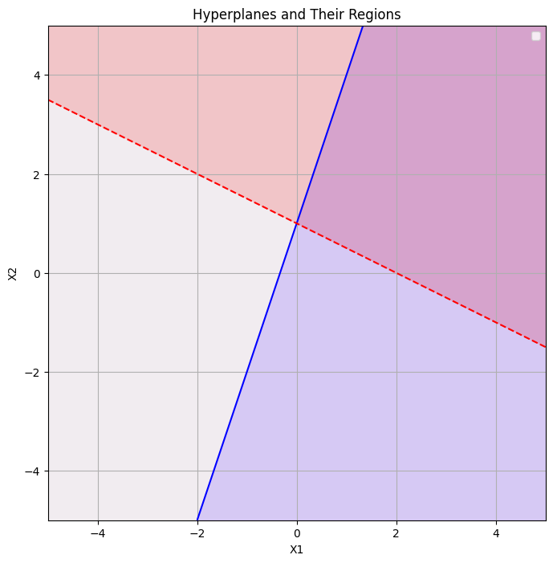

```python
import numpy as np
import matplotlib.pyplot as plt

# Create a grid of points
x1 = np.linspace(-5, 5, 100)
x2 = np.linspace(-5, 5, 100)
X1, X2 = np.meshgrid(x1, x2)

# Hyperplane 1: 1 + 3X1 - X2 = 0
Z1 = 1 + 3 * X1 - X2

# Hyperplane 2: -2 + X1 + 2X2 = 0
Z2 = -2 + X1 + 2 * X2

# Plot
plt.figure(figsize=(8, 8))

# Hyperplane 1
plt.contour(X1, X2, Z1, levels=[0], colors='blue', linestyles='solid')
plt.contourf(X1, X2, Z1, levels=[0, np.max(Z1)], alpha=0.2, colors='blue', label='1 + 3X1 - X2 > 0')
plt.contourf(X1, X2, Z1, levels=[np.min(Z1), 0], alpha=0.2, colors='lightblue', label='1 + 3X1 - X2 < 0')

# Hyperplane 2
plt.contour(X1, X2, Z2, levels=[0], colors='red', linestyles='dashed')
plt.contourf(X1, X2, Z2, levels=[0, np.max(Z2)], alpha=0.2, colors='red', label='-2 + X1 + 2X2 > 0')
plt.contourf(X1, X2, Z2, levels=[np.min(Z2), 0], alpha=0.2, colors='pink', label='-2 + X1 + 2X2 < 0')

plt.xlabel('X1')
plt.ylabel('X2')
plt.title('Hyperplanes and Their Regions')
plt.grid(True)
plt.legend(['1 + 3X1 - X2 = 0', '-2 + X1 + 2X2 = 0'])
plt.show()
```

### Explanation of the Plot

- **Blue line:** `1 + 3X₁ - X₂ = 0` (slope 3, intercept 1)
- **Blue shading:** Region where `1 + 3X₁ - X₂ > 0` (below the line, i.e., `X₂ < 3X₁ + 1`)
- **Light blue shading:** Region where `1 + 3X₁ - X₂ < 0` (above the line)
- **Red dashed line:** `-2 + X₁ + 2X₂ = 0` (slope -1/2, intercept 1)
- **Red shading:** Region where `-2 + X₁ + 2X₂ > 0` (above the line)
- **Pink shading:** Region where `-2 + X₁ + 2X₂ < 0` (below the line)

### Answer for Question 1

**(a)**  
The hyperplane `1 + 3X₁ - X₂ = 0` is a straight line with equation `X₂ = 3X₁ + 1`.

- The region where `1 + 3X₁ - X₂ > 0` is **below** the line (i.e., `X₂ < 3X₁ + 1`)
- The region where `1 + 3X₁ - X₂ < 0` is **above** the line
- You can sketch it using points: (0, 1), (1, 4), (-1, -2)

**(b)**  
The hyperplane `-2 + X₁ + 2X₂ = 0` becomes `X₂ = -0.5X₁ + 1`

- The region where `-2 + X₁ + 2X₂ > 0` is **above** the line (i.e., `X₂ > -0.5X₁ + 1`)
- The region where `-2 + X₁ + 2X₂ < 0` is **below** the line
- Use points like (0, 1), (2, 0), (-2, 2) to draw it
- Use the provided code to plot both hyperplanes and shaded regions on the same graph

### Question 2: Non-Linear Decision Boundary

**Task:**

**(a)** Sketch the curve `(1 + X₁)² + (2 - X₂)² = 4`  
**(b)** Indicate regions where `(1 + X₁)² + (2 - X₂)² > 4` and `≤ 4`  
**(c)** Classify the points (0, 0), (-1, 1), (2, 2), (3, 8) into blue or red classes  
**(d)** Argue that the decision boundary is non-linear in `X₁, X₂` but linear in `X₁, X₁², X₂, X₂²`

### Understanding the Concepts

**Non-Linear Decision Boundary (Section 9.3.1):**  
Support Vector Machines (SVMs) can classify non-linear regions by adding polynomial features (e.g., `X₁²`) to create linear boundaries in higher-dimensional space.

**Support Vector Machine (Section 9.3.2):**  
SVMs use kernels to implicitly map data into a higher-dimensional feature space to create effective (often non-linear) decision boundaries.

### Part (a): Sketch the Curve

- **Equation:** `(1 + X₁)² + (2 - X₂)² = 4`
- **Rewriting it:**  
  `(X₁ + 1)² + (X₂ - 2)² = 2²`
- This is a **circle** centered at **(-1, 2)** with radius **2**
- Points on the circle:
  - Right: (1, 2)
  - Left: (-3, 2)
  - Top: (-1, 4)
  - Bottom: (-1, 0)

### Part (b): Regions

- **Inside the circle:**  
  `(1 + X₁)² + (2 - X₂)² ≤ 4` — includes boundary and interior
- **Outside the circle:**  
  `(1 + X₁)² + (2 - X₂)² > 4` — any point further than 2 units from center (-1, 2)

**Examples:**

- Center (-1, 2): `(0)² + (0)² = 0 ≤ 4` → inside
- Point (0, 0): `(1)² + (2)² = 1 + 4 = 5 > 4` → outside

### Part (c): Classify Points

- (0, 0): `(1 + 0)² + (2 - 0)² = 1 + 4 = 5 > 4` → **Blue**
- (-1, 1): `(1 - 1)² + (2 - 1)² = 0 + 1 = 1 ≤ 4` → **Red**
- (2, 2): `(1 + 2)² + (2 - 2)² = 9 + 0 = 9 > 4` → **Blue**
- (3, 8): `(1 + 3)² + (2 - 8)² = 16 + 36 = 52 > 4` → **Blue**

### Part (d): Linear or Non-Linear?

- The decision boundary `(1 + X₁)² + (2 - X₂)² = 4` is **non-linear** in terms of `X₁` and `X₂`.
- But if we **transform** the features to include `X₁²`, `X₂²`, then the equation becomes linear:
  - Let `Z₁ = X₁`, `Z₂ = X₁²`, `Z₃ = X₂`, `Z₄ = X₂²`
  - In this transformed space, the boundary becomes a linear combination of these terms.
- Therefore, the boundary is linear in an **expanded feature space**, but **non-linear** in the original.

### Python Code for Visualization

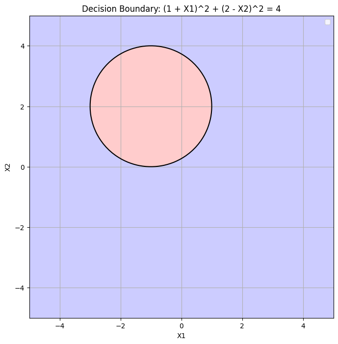

```python
import numpy as np
import matplotlib.pyplot as plt

# Create a grid
x1 = np.linspace(-5, 5, 100)
x2 = np.linspace(-5, 5, 100)
X1, X2 = np.meshgrid(x1, x2)

# Equation: (1 + X1)^2 + (2 - X2)^2
Z = (1 + X1)**2 + (2 - X2)**2

# Plot
plt.figure(figsize=(8, 8))
plt.contour(X1, X2, Z, levels=[4], colors='black', linestyles='solid')
plt.contourf(X1, X2, Z, levels=[0, 4], alpha=0.2, colors='red', label='(1 + X1)^2 + (2 - X2)^2 <= 4')
plt.contourf(X1, X2, Z, levels=[4, np.max(Z)], alpha=0.2, colors='blue', label='(1 + X1)^2 + (2 - X2)^2 > 4')
plt.xlabel('X1')
plt.ylabel('X2')
plt.title('Decision Boundary: (1 + X1)^2 + (2 - X2)^2 = 4')
plt.grid(True)
plt.legend(['Boundary', 'Red Class (<= 4)', 'Blue Class (> 4)'])
plt.show()
```

### Additional Notes for Question 2

- **Red shading:** Inside and on the circle (`≤ 4`)
- **Blue shading:** Outside the circle (`> 4`)

### Part (c): Classify Points

**Rule:**

- **Blue class** if `(1 + X₁)² + (2 - X₂)² > 4`
- **Red class** if `(1 + X₁)² + (2 - X₂)² ≤ 4`

**Points:**

- (0, 0): `(1 + 0)² + (2 - 0)² = 1 + 4 = 5 > 4` → **Blue**
- (-1, 1): `(1 - 1)² + (2 - 1)² = 0 + 1 = 1 ≤ 4` → **Red**
- (2, 2): `(1 + 2)² + (2 - 2)² = 9 + 0 = 9 > 4` → **Blue**
- (3, 8): `(1 + 3)² + (2 - 8)² = 16 + 36 = 52 > 4` → **Blue**

### Part (d): Linear vs. Non-Linear Decision Boundary

**Non-Linear in `X₁, X₂`:**  
The decision boundary `(1 + X₁)² + (2 - X₂)² = 4` describes a **circle**, not a line.  
A **linear** decision boundary in 2D is of the form:  
`β₀ + β₁X₁ + β₂X₂ = 0` — which defines a straight line.  
Since the circle includes **squared terms** (`X₁²`, `X₂²`), it's inherently **non-linear** in the original space.

**Linear in `X₁, X₁², X₂, X₂²`:**  
Let's expand the boundary equation:

```
(1 + X₁)² + (2 - X₂)² = 4
→ 1 + 2X₁ + X₁² + 4 - 4X₂ + X₂² = 4
→ X₁² + X₂² + 2X₁ - 4X₂ + 1 = 0
```

This is a **linear equation in the transformed features**:  
`X₁, X₁², X₂, X₂²`

In this new space (with 4 dimensions), the decision boundary is a **hyperplane**, which SVMs can find using a linear kernel after transformation (see Section 9.3.2).  
This is the core idea behind kernel methods — transforming non-linear patterns into linear separability in higher-dimensional spaces.

### Answer for Question 2

**(a)**  
The curve `(1 + X₁)² + (2 - X₂)² = 4` is a **circle** centered at (-1, 2) with radius 2.  
Plot points like: (-1, 4), (-1, 0), (1, 2), (-3, 2)

**(b)**

- Region where the value is `≤ 4`: **Inside/on the circle** → Red class
- Region where value is `> 4`: **Outside the circle** → Blue class  
  Use the Python code provided to visualize this clearly.

**(c)**  
Point classifications:

- (0, 0): **Blue** (5 > 4)
- (-1, 1): **Red** (1 ≤ 4)
- (2, 2): **Blue** (9 > 4)
- (3, 8): **Blue** (52 > 4)

**(d)**  
The decision boundary is:

- **Non-linear in `X₁, X₂`** because it's a circle
- **Linear in `X₁, X₁², X₂, X₂²`** because the equation can be written as a linear combination of these features:  
  `X₁² + X₂² + 2X₁ - 4X₂ + 1 = 0`

This aligns with how Support Vector Machines handle non-linear problems using feature transformations or kernels.